# Practical Machine Learning Project Course

Gerard

2022-08-04

## SUMMARY

In this project, we will use data from accelerometers on the belt, forearm, arm, and dumbell of 6 participants to predict the manner in which they did the exercise.  
The subjects were asked to perform a one handed dumbbell “biceps curl” in five different ways labelled A - E (A being ‘correct’ and B - E being four different kinds of deviation). For more information, visit http://groupware.les.inf.puc-rio.br/har

## Data Processing

Load packages

```r
library(tidyverse)
library(caret)
library(gbm)
```

Read in the Data

```r
train_url<-"https://d396qusza40orc.cloudfront.net/predmachlearn/pml-training.csv"
test_url<-"https://d396qusza40orc.cloudfront.net/predmachlearn/pml-testing.csv"
training<-read_csv(train_url)
testing<-read_csv(test_url)
```

### Explore data

Let’s take a quick look at the data.

```r
dim(training)
```

```
## [1] 19622   160
```

```r
dim(testing)
```

```
## [1]  20 160
```

```r
summary(training[1:20])
```

```
##       ...1        user_name         raw_timestamp_part_1 raw_timestamp_part_2
##  Min.   :    1   Length:19622       Min.   :1.322e+09    Min.   :   294
##  1st Qu.: 4906   Class :character   1st Qu.:1.323e+09    1st Qu.:252912
##  Median : 9812   Mode  :character   Median :1.323e+09    Median :496380
##  Mean   : 9812                      Mean   :1.323e+09    Mean   :500656
##  3rd Qu.:14717                      3rd Qu.:1.323e+09    3rd Qu.:751891
##  Max.   :19622                      Max.   :1.323e+09    Max.   :998801
##
##  cvtd_timestamp      new_window          num_window      roll_belt
##  Length:19622       Length:19622       Min.   :  1.0   Min.   :-28.90
##  Class :character   Class :character   1st Qu.:222.0   1st Qu.:  1.10
##  Mode  :character   Mode  :character   Median :424.0   Median :113.00
##                                        Mean   :430.6   Mean   : 64.41
##                                        3rd Qu.:644.0   3rd Qu.:123.00
##                                        Max.   :864.0   Max.   :162.00
##
##    pitch_belt          yaw_belt       total_accel_belt kurtosis_roll_belt
##  Min.   :-55.8000   Min.   :-180.00   Min.   : 0.00    Length:19622
##  1st Qu.:  1.7600   1st Qu.: -88.30   1st Qu.: 3.00    Class :character
##  Median :  5.2800   Median : -13.00   Median :17.00    Mode  :character
##  Mean   :  0.3053   Mean   : -11.21   Mean   :11.31
##  3rd Qu.: 14.9000   3rd Qu.:  12.90   3rd Qu.:18.00
##  Max.   : 60.3000   Max.   : 179.00   Max.   :29.00
##
##  kurtosis_picth_belt kurtosis_yaw_belt  skewness_roll_belt skewness_roll_belt.1
##  Length:19622        Length:19622       Min.   :-5.745     Length:19622
##  Class :character    Class :character   1st Qu.:-0.444     Class :character
##  Mode  :character    Mode  :character   Median : 0.000     Mode  :character
##                                         Mean   :-0.026
##                                         3rd Qu.: 0.417
##                                         Max.   : 3.595
##                                         NA's   :19225
##  skewness_yaw_belt  max_roll_belt     max_picth_belt  max_yaw_belt
##  Length:19622       Min.   :-94.300   Min.   : 3.00   Length:19622
##  Class :character   1st Qu.:-88.000   1st Qu.: 5.00   Class :character
##  Mode  :character   Median : -5.100   Median :18.00   Mode  :character
##                     Mean   : -6.667   Mean   :12.92
##                     3rd Qu.: 18.500   3rd Qu.:19.00
##                     Max.   :180.000   Max.   :30.00
##                     NA's   :19216     NA's   :19216
```

The training data set contains 19622 observations and 160 variables, while the testing data set contains 20 observations and 160 variables. The “classe” variable in the training set is the outcome to predict.

### Clean data

In the previous step we could also see some variables with most of the observations being NA’s. We will get rid of these as well as some meaningless variables, such as “…1”, “user_name”, and some time related variables.

Remove columns with more than 20% NA’s

```r
train_na<-apply(training,2,function(x)sum(is.na(x)))
test_na<-apply(testing,2,function(x)sum(is.na(x)))
keepTrain<-(train_na/dim(training)[1])<0.2
train<-training[,keepTrain]
test<-testing[,keepTrain]
```

Remove columns not important for prediction

```r
train<-train[,-c(1:7)]
test<-test[,-c(1:7)]
```

We also looked for variables with near zero variance with the code below but found none:

```r
nzv<-nearZeroVar(train) ## none found
```

Set outcome variable “classe” as factor

```r
train$classe<-as.factor(train$classe)
```

# Model fitting

Now that we have the data clean and ready we will look to fit a model for prediction.

### Split training set in training and cross validation

Fist we will divide the data in a training set and a cross validation set that we’ll use to evaluate the performance of our models.

```r
set.seed(12345)
trainIndex<-createDataPartition(train$classe,p=.7,list=F)
trainSet<-train[trainIndex,]
cv<-train[-trainIndex,]
```

### Fit different models

We will fit two different different models, Random Forests and Stochastic Gradient Boosting, to see which fits the data better. To train the model and find the best parameters for the models we’ll use 10-fold cross validation.

```r
cvCtrl <- trainControl(method = "cv", number = 10)
m_rf<-train(classe~.,data=trainSet,method="rf",trControl=cvCtrl)
m_gbm<-train(classe~.,data=trainSet,method="gbm",trControl=cvCtrl,verbose=F)
```

### Predict classes

Now we’ll predict the classes on the cross validation set using both models and calculate their accuracy.

```r
pred_rf<- predict(m_rf,cv)
pred_gbm<-predict(m_gbm,cv)
postResample(pred_rf,cv$classe)
```

```
##  Accuracy     Kappa
## 0.9952421 0.9939813
```

```r
postResample(pred_gbm,cv$classe)
```

```
##  Accuracy     Kappa
## 0.9610875 0.9507660
```

# Predict values on the test set

We’ll use the RF model obtained previously to make predictions on the test set.

```r
predTest<-predict(m_rf,test)
```

# Appendix

Plot Decision Tree

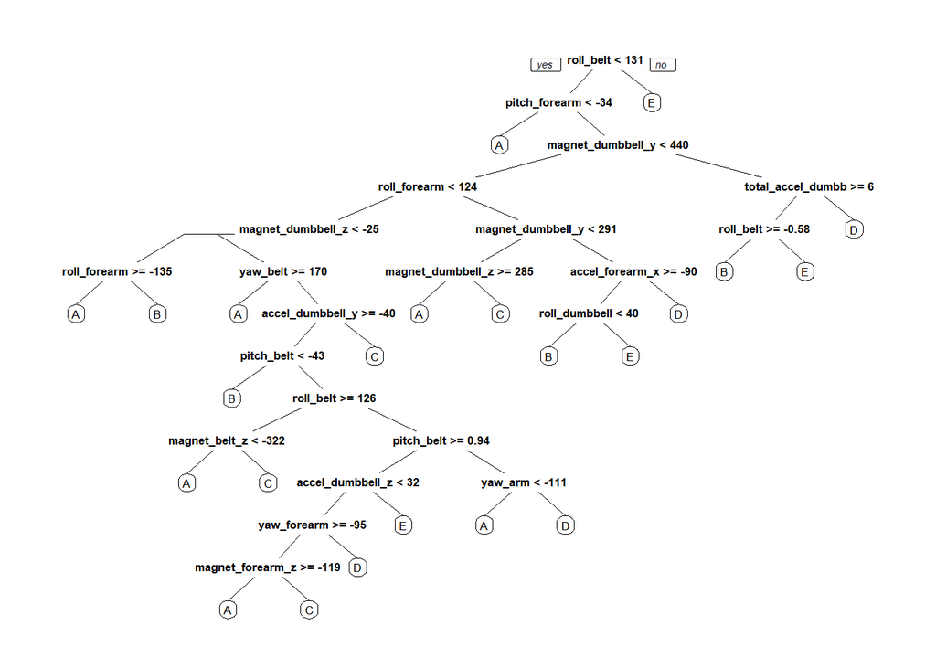

```r
library(rpart.plot)
treeModel <- rpart(classe ~ ., data=trainSet, method="class")
prp(treeModel)
```